# Imports

```python
"""
some pacakges needed for all th plots made here, most are for plotting, install as needed

pip install scipy
pip install h5py
pip install matplotlib
pip install opencv-python
pip install seaborn
pip install matplotlib
pip install ipywidgets
pip install matplotlib install ipywidgets
pip install opencv-pythonjupyter nbextension enable --py widgetsnbextension
pip install ipython
pip install WordCloud
pip install geopy
pip install scipy
pip install plotly
pip install nbformat --upgrade
pip install folium
pip install geopandas
pip install scikit-learn
pip install cairosvg


"""
```

[output not shown]

```python
from selenium import webdriver
from selenium.webdriver.common.keys import Keys
from selenium.webdriver.support.ui import WebDriverWait
from selenium.webdriver.support import expected_conditions as EC
from selenium.webdriver.common.by import By
from selenium.webdriver.chrome.service import Service
from selenium.webdriver.chrome.options import Options
from selenium.webdriver.common.action_chains import ActionChains
import pandas as pd
from dotenv import load_dotenv
import os
import openai

from bs4 import BeautifulSoup
import re
import time
import pickle
import numpy as np
import pandas as pd

from scrapifurs import utils
from scrapifurs.GPTinstructions import GPTinstructions

from tqdm import tqdm

import seaborn as sns
import matplotlib.pyplot as plt
import numpy as np

from scipy.cluster.hierarchy import linkage, leaves_list

from geopy.geocoders import Nominatim
from geopy.distance import geodesic


import plotly.express as px


import plotly.graph_objects as go
```

```python
def get_lat_lon(locations):
    geolocator = Nominatim(user_agent="example.lastname@gmail.com")
    lat_lon_data = {}
    for location in tqdm(locations):
        location_data = geolocator.geocode(location)
        if location_data is not None:
            lat_lon_data[location] = (location_data.latitude, location_data.longitude)
        else:
            lat_lon_data[location] = (None, None)
    return lat_lon_data

def calculate_distances(lat_lon_data, target_loc_str):
    target_location = get_lat_lon([target_loc_str])[target_loc_str]
    if target_location[0] is None:
        raise ValueError("No latitude and longitude found for the provided location.")
    distances = {}
    for location, loc_lat_lon in lat_lon_data.items():
        if loc_lat_lon[0] is not None:
            distance = geodesic(target_location, loc_lat_lon).miles
            distances[location] = distance
        else:
            distances[location] = None
    return distances





def jaccard_similarity(str1, str2):
    set1 = set(str1.split())
    set2 = set(str2.split())
    union_length = len(set1.union(set2))
    if union_length == 0:
        return np.nan
    return len(set1.intersection(set2)) / union_length


class GPT_StringDataCleaner:
    def __init__(self, original_df, key_name, instructions, overwrite_cleaned_key = True, model="gpt-4"):
        self.original_df = original_df
        self.key_name = key_name
        self.instructions = instructions
        self.model = model
        self.clean_key = key_name + '_CLEANED_BY_GPT'
        self.overwrite_cleaned_key = overwrite_cleaned_key

    def send_to_gpt(self):
        self.unique_names = sorted(self.original_df[self.key_name].unique())

        messages = [{"role": "system", "content": self.instructions}]
        messages.append({"role": "user", "content": str(self.unique_names)})
        chat = openai.ChatCompletion.create(model=self.model, messages=messages)
        self.reply = chat.choices[0].message.content
    def test_lengths(self):
        print(f" len input is {len(self.unique_names)}, but len output is {len(cleaned_data)}")
    def process_data(self):
        cleaned_data =  eval(self.reply)

        if len(self.unique_names) != len(cleaned_data):
            print(f" len input is {len(self.unique_names)}, but len output is {len(cleaned_data)}")
            raise ValueError("Input and output lists must have the same length")

        temp_df = pd.DataFrame({self.key_name: self.unique_names, self.clean_key: cleaned_data})
        # delete cleaned key data if we want to overwrite
        if self.clean_key in self.original_df.columns and self.overwrite_cleaned_key:
            self.original_df = self.original_df.drop(self.clean_key, axis=1)
        if self.clean_key not in self.original_df.columns:
            merged_df = pd.merge(self.original_df, temp_df[[self.clean_key, self.key_name]],
                                 on=self.key_name, how='left')
            self.original_df[self.clean_key] = merged_df[self.clean_key]
            merged_df = None

        return self.original_df
```

### INIT API key, intrucitons for GPT which can be saved as text files in the correct data/instrucitons dir of the package

```python
# setup API key for chatGPT
load_dotenv()  # take environment variables from .env.
os.environ["OPENAI_API_KEY"]  = os.getenv("OPENAI_API_KEY")
openai.api_key = os.environ["OPENAI_API_KEY"]
```

# Info_dict to set up all used variables

```python
# setup basic variable as dict
info_dict = {'init_url':'https://www.linkedin.com/',
             'save_password_dir':'/Users/phil/Dropbox/GITHUB/DATA/scrapifurs/saved_cookies/',
             'start_url':'https://www.linkedin.com/search/results/people/?keywords=data%20scientist&origin=CLUSTER_EXPANSION&sid=fRq'}
info_dict['full_cookies_save_path'] = info_dict['save_password_dir']+os.sep+"linkedin_cookies.pkl"
```

# Scraping step

### create rules to trim text based on key workds and search characteristics

this willl help reduce the amount of data we pass to GPT API and reduce costs

```python
text_finder = utils.StringSectionExtractor()
text_finder.add_start_rule('search result pages', False)
text_finder.add_end_rule('Page \d+ of \d+', True)
text_finder.add_end_rule("these results helpful", False)
text_finder.add_end_rule("messaging overlay", False)
```

### INIT: chrome browser, login, save cookies (future login)

```python
#init chrome
chrome_options = Options()
chrome_options.add_argument("--disable-extensions")
chrome_options.add_argument("--disable-gpu")
chrome_options.add_argument("--no-sandbox")
driver = webdriver.Chrome(options=chrome_options)

driver.get(info_dict['init_url'])
time.sleep(1)
driver.get(info_dict['init_url'])# reload becasue sometimes it doesnt load
time.sleep(2)


# Load cookies if they exist
try:
    cookies = pickle.load(open(info_dict['full_cookies_save_path'], "rb"))
    for cookie in cookies:
        driver.add_cookie(cookie)
    driver.refresh()
    assert(not not cookies)# if empty try a different method
except:
    print("No cookies found. Manual login required.")
    # If not logged in
    input('Please login and press Enter to continue...')
    pickle.dump(driver.get_cookies(), open(info_dict['full_cookies_save_path'], "wb")) # save cookies after login
```

for this example must reduce window size to 25% (or implement scrolling with rescanning) to gather data. zooming out manually is necessary

```python
input('''set zoom to 25% for winow to see all website data that it needs, press enter to continue''')
```

```
set zoom to 25% for winow to see all website data that it needs, press enter to continue
```

```
''
```

#### navigate to the first page we want to scrape (note this is customized to linkedin search people pages but can easily be adapted to ther sources)

```python
driver.get(info_dict['start_url'])
all_text = []
```

#### scrape all the pages moving from one page to the next and save

```python
f_name = '/Users/phil/Dropbox/GITHUB/DATA/scrapifurs/linked_in_search_saves/extractedLinkedinSearchDataRawText.pkl'
collect_n_pages = 60
n_times = np.random.uniform(12, 28, collect_n_pages)# randomize the wait times a little bit to prevent robotic like behavior
for k in n_times:
    time.sleep(k)
    url_text = utils.get_lxml_text(driver, remove_empty_lines=True)
    text_data = text_finder.extract(url_text)
    all_text.append(text_data)
    utils.click_next_button(driver)

utils.save_obj(all_text, f_name)
# with open(f_name, 'wb') as f:
#     pickle.dump(all_text, f)
```

```python
## not included b/c I dont want to include names of people
# f_name = '/Users/phil/Dropbox/GITHUB/DATA/scrapifurs/linked_in_search_saves/extractedLinkedinSearchDataRawText.pkl'
# all_text = utils.load_obj(f_name)
```

## Some data is inconsistent (empty pages etc)

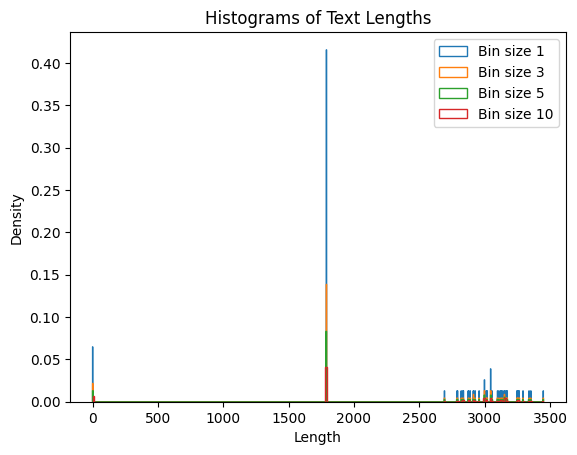

```python
bin_widths = [1, 3, 5, 10]

data = [len(k) for k in all_text]
# Loop through the bin sizes and plot the histograms
for w in bin_widths:
    plt.hist([len(k) for k in all_text], bins=np.arange(min(data), max(data) + w, w),density=True, histtype='step', label=f'Bin size {w}')

plt.xlabel('Length')
plt.ylabel('Density')
plt.title('Histograms of Text Lengths')
plt.legend()
plt.show()
```

#### Create a heatmap to find scraped data that is inconsistnat with previous data.

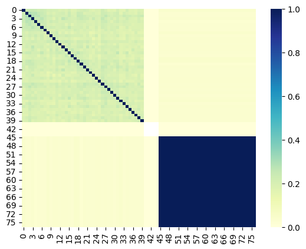

```python
similarity_matrix = [[jaccard_similarity(doc1, doc2) for doc2 in all_text] for doc1 in all_text]
sns.heatmap(similarity_matrix, annot=False, cmap="YlGnBu")
plt.show()
```

only the first 39 pages have good data as you can see below

```python
selected_text = all_text[39][:200]
print('--REAL DATA--\n'+selected_text[:52] +"FIRST_NAME   LAST_NAME" +selected_text[84:])
print('--EMPTY--\n'+all_text[40][:200])# empty
print('--NO SEARCH RESULTS--\n'+all_text[-1][:200])# no search results
```

```
--REAL DATA--
.
About 621,000 results
          Status is offline
FIRST_NAME   LAST_NAME PhD’s profile
• 2nd2nd degree connection
• 2nd2nd degree connection
Sr. Data Scientist at Intuit
Los Angeles Metrop
--EMPTY--

--NO SEARCH RESULTS--
.
      No results found
  Try shortening or rephrasing your search.
          Edit search
                        About
                        Accessibility
                        Talent Solutions
```

# Chat GPT extract scraped data

#### Get instructions to make sure consistent cleaning instructions from GPT

note: instructions were tested in chatGPT and then once I verified the outcome, I asked chatGPT to then give me clear instructions for reproducibility

```python
# allow you to save instructions to append ot the beginning of a GPT command based on the txt files in
# the data directory (or set a custom directory). modular for the many different commands and instructions
# we will need.
instructions = GPTinstructions()

# # Print all instructions keys
# instructions.print_instructions()
gpt_instructions = instructions.get_instruction("linkedinSearchExtractNamesDF")

print(gpt_instructions)
```

```
Extract the names: Please look for patterns indicating a person's name. Names are usually proper nouns and are generally the first information provided in each data point.

    Find the job titles: Please identify each person's job title. This information follows the name and often contains phrases such as 'Data Scientist', 'Neuroscientist', 'Senior Associate Data Scientist', or a variant that includes the role and any additional qualifiers.

    Identify the job location: This information typically follows the job title and is usually a city or metropolitan area, such as 'Pasadena, CA' or 'Los Angeles Metropolitan Area'.

    Find the company names: The company names usually follow the job location. In case there is no current company mentioned, or the person is actively seeking a job, make a note of that by using placeholders like 'None (Job Seeking)' or 'None (No Company Mentioned)'.

    Construct the dictionary: Organize all the extracted information into a dictionary format where the key represents the type of information (e.g., 'Name', 'Job Titles', 'Job Location', 'Company Name') and the value is a list of all the extracted information of that type in the order of appearance…

    Formatting the instructions: Always make sure to start the code block with a comment '##BEGIN##', fill in the data accordingly, and end it with '##END##'. All columns of data should align with each other.

    For example:


    ##BEGIN##

    DF_TEMP = {
        "Name": ["Person 1", "Person 2", ...],
        "Job Titles": ["Job 1", "Job 2", ...],
        "Job Location": ["Location 1", "Location 2", ...],
        "Company Name": ["Company 1", "Company 2", ...]
    }

    ##END##


    Replace "Person 1", "Job 1", "Location 1", "Company 1", etc., with the actual extracted data.

    Please make sure to follow these instructions to achieve consistent results.


    here is the text:
```

#### pull out data using CHAT GPT API

```python
## not included b/c I dont want to include names of people
# f_name = '/Users/phil/Dropbox/GITHUB/DATA/scrapifurs/linked_in_search_saves/extractedLinkedinSearchDataRawText.pkl'
# all_text = utils.load_obj(f_name)
```

```python
text_2_process = all_text[:39] # filtered based on above analysis only the real data
```

```python
columns = ["Name", "Job Titles", "Job Location", "Company Name"]
df = pd.DataFrame(columns=columns)
all_chats = []# just in case we get abnormal results lets save all our raw chat outputs

for kk, gpt_text in enumerate(tqdm(text_2_process)):
    messages = [ {"role": "system", "content": gpt_instructions} ]
    messages.append({"role": "user", "content": gpt_text})
    chat = openai.ChatCompletion.create(model="gpt-3.5-turbo", messages=messages)
    all_chats.append(chat)
    try:
        reply = chat.choices[0].message.content
        tmp1 = reply.split('##BEGIN##')[-1].split('##END##')[0]
        DF_TEMP = None
        exec(tmp1);
        DF_TEMP = pd.DataFrame(DF_TEMP)
        df= pd.concat([df, DF_TEMP], ignore_index=True)
    except Exception as e:
        warning_msg = f"An exception occurred at index {kk} with content {gpt_text[:50]}. Error details: {str(e)}"
        warnings.warn(warning_msg)
```

#### Save data as pickle or csv

```python
# f_name = '/Users/phil/Dropbox/GITHUB/DATA/scrapifurs/pandas_df/final_df_data_scientist_search_v1'
# utils.save_obj(df, f_name+'.pkl', pickle.HIGHEST_PROTOCOL)
# # df.to_csv(f_name+'.csv', index=False)
```

# data cleaning

#### Load data frame (if not already in memory) and drop names for privacy

```python
df = utils.load_obj('/Users/phil/Dropbox/GITHUB/scrapifurs/scrapifurs/data/final_df_data_scientist_search_v1.pkl')
# df = df.drop('Name', axis=1)
df
```

|  | Job Titles | Job Location | Company Name |
| --- | --- | --- | --- |
| 0 | Incoming Data Scientist at Chevron \| USC Alum | Los Angeles, CA | Chevron |
| 1 | Data Scientist at eBay | Los Angeles, CA | eBay |
| 2 | Data Scientist at Twitter | Los Angeles Metropolitan Area | Twitter |
| 3 | Data Scientist \| Petroleum Engineer | Los Angeles Metropolitan Area | Phillips 66 |
| 4 | Data Scientist at Snap Inc. | Los Angeles Metropolitan Area | Snap Inc. |
| ... | ... | ... | ... |
| 373 | Data Scientist | Los Angeles Metropolitan Area | Data Scientist II at Nordstrom |
| 374 | Data Scientist | Los Angeles, CA | Data Scientist at BCG GAMMA |
| 375 | Data Scientist | Los Angeles, CA | Data Scientist at Rule14 LLC |
| 376 | Data Analyst \| Data Scientist | Los Angeles Metropolitan Area | None (No Company Mentioned) |
| 377 | Data Science Intern @ Chewy | Los Angeles, CA | Data Scientist at Chewy |

378 rows × 3 columns

## duplicate locations

this is overkill since we can just look at the list but this is an example of what we could do for a larger list where this visualization may be more useful

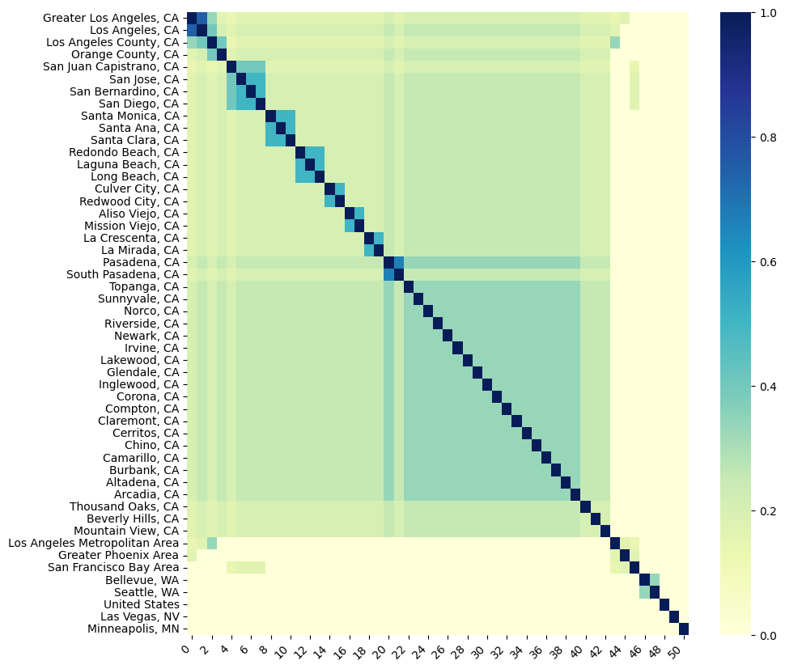

```python
data_in = sorted(df['Job Location'].unique())

# Assuming similarity_matrix is your similarity matrix
similarity_matrix = [[jaccard_similarity(doc1, doc2) for doc2 in data_in] for doc1 in data_in]

# Perform hierarchical clustering
Z = linkage(similarity_matrix, method='average')
order = leaves_list(Z)

# Reorder the rows and columns of the similarity matrix based on clustering
reordered_similarity_matrix = [[similarity_matrix[i][j] for j in order] for i in order]
reordered_data_in = [data_in[i] for i in order]

# Plot the reordered similarity matrix
plt.figure(figsize=[10, 10])
sns.heatmap(reordered_similarity_matrix, annot=False, cmap="YlGnBu", yticklabels=reordered_data_in)
plt.xticks(rotation=45, ha="right") # Optionally, to rotate x labels for better visibility
plt.show()
```

again overkill to use GPT here but it could be useful to identify locations we are not familiar with that may represent the same area. more useful for larger dataset wehre there are 500+ unique locations

```python
locations_in = '\n'.join(sorted(df['Job Location'].unique()))

intructions_cleaning = """
Check this data, are there any locations that could be considered the the same location.
I want all places that mean the same thing to be the exact same string.
Point out any duplicates that dont have the same string (either due to case-sensitive, difference in spelling or from different terminologies)
for each, set up suplicate locations with different name format the output as a python list.
"""
messages = [ {"role": "system", "content": intructions_cleaning} ]
messages.append({"role": "user", "content": locations_in})
chat = openai.ChatCompletion.create(model="gpt-4", messages=messages)
```

```python
print(chat.choices[0].message.content)
```

```
The places that can be considered the same are

1. "Greater Los Angeles, CA", "Los Angeles County, CA", "Los Angeles Metropolitan Area" and "Los Angeles, CA"

2. "San Francisco Bay Area" can include "Mountain View, CA", "Newark, CA", "Redwood City, CA", "San Jose, CA", "Santa Clara, CA", "Sunnyvale, CA", although not always.

The Python list format of these places would be:

duplicate_locations = [["Greater Los Angeles, CA", "Los Angeles County, CA", "Los Angeles Metropolitan Area", "Los Angeles, CA"], ["San Francisco Bay Area", "Mountain View, CA", "Newark, CA", "Redwood City, CA", "San Jose, CA", "Santa Clara, CA", "Sunnyvale, CA"]]
```

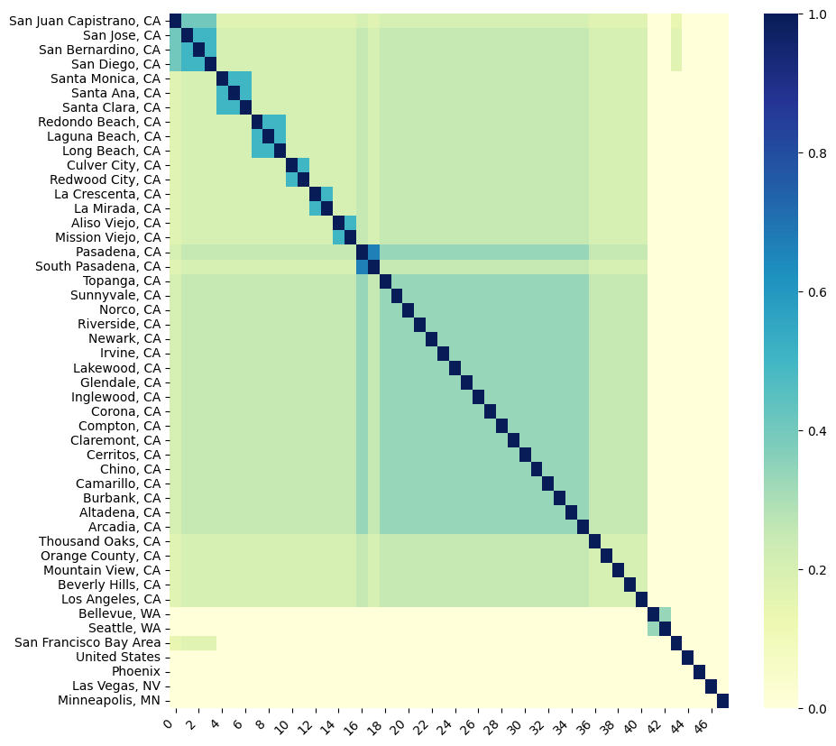

```python
def clean_location(location):
    if 'greater' in location.lower():
        location = location.replace('Greater', '')
        location = location.replace('Area', '')
    return location.strip()

# remove "grater XXXX area" since this screws up finding location using geopy
df['Job Location'] = df['Job Location'].apply(clean_location)


# Define the list of duplicates
duplicates = ["Greater Los Angeles, CA", "Los Angeles County, CA", "Los Angeles Metropolitan Area", "Los Angeles, CA"]

# Replace all instances of values in duplicates list with set_value
df['Job Location'] = df['Job Location'].replace(duplicates, "Los Angeles, CA")
locations_in = '\n'.join(sorted(df['Job Location'].unique()))

data_in = sorted(df['Job Location'].unique())

# Assuming similarity_matrix is your similarity matrix
similarity_matrix = [[jaccard_similarity(doc1, doc2) for doc2 in data_in] for doc1 in data_in]

# Perform hierarchical clustering
Z = linkage(similarity_matrix, method='average')
order = leaves_list(Z)

# Reorder the rows and columns of the similarity matrix based on clustering
reordered_similarity_matrix = [[similarity_matrix[i][j] for j in order] for i in order]
reordered_data_in = [data_in[i] for i in order]

# Plot the reordered similarity matrix
plt.figure(figsize=[10, 10])
sns.heatmap(reordered_similarity_matrix, annot=False, cmap="YlGnBu", yticklabels=reordered_data_in)
plt.xticks(rotation=45, ha="right") # Optionally, to rotate x labels for better visibility
plt.show()
```

## the job title and company data are messy, some people put both the title and the company in the same idenfier (e.g. under company they put , "data scientist at Amazon")

```python
instructions = """
for this list of names output a python list with only the company names and no other extraneous details.
if names appear insoncistant (e.g. amazon and AMAZON) change them to all be the same name

so for example "Data Scientist at Aviana Global Technologies, Inc." woudl return "Aviana Global Technologies"
every value of the input list should have a corresponding value for the output.
"""

cleaner = GPT_StringDataCleaner(df, 'Company Name', instructions)
cleaner.send_to_gpt()


# print(cleaner.reply)
exec("cleaned_data = "+cleaner.reply)
len(cleaned_data), len(cleaner.unique_names)
```

```
(267, 267)
```

```python
df = cleaner.process_data()
df
```

|  | Job Titles | Job Location | Company Name | Company Name_CLEANED_BY_GPT |
| --- | --- | --- | --- | --- |
| 0 | Incoming Data Scientist at Chevron \| USC Alum | Los Angeles, CA | Chevron | Chevron |
| 1 | Data Scientist at eBay | Los Angeles, CA | eBay | eBay |
| 2 | Data Scientist at Twitter | Los Angeles, CA | Twitter | Twitter |
| 3 | Data Scientist \| Petroleum Engineer | Los Angeles, CA | Phillips 66 | Phillips 66 |
| 4 | Data Scientist at Snap Inc. | Los Angeles, CA | Snap Inc. | Snap Inc. |
| ... | ... | ... | ... | ... |
| 373 | Data Scientist | Los Angeles, CA | Data Scientist II at Nordstrom | Nordstrom |
| 374 | Data Scientist | Los Angeles, CA | Data Scientist at BCG GAMMA | BCG GAMMA |
| 375 | Data Scientist | Los Angeles, CA | Data Scientist at Rule14 LLC | Rule14 LLC |
| 376 | Data Analyst \| Data Scientist | Los Angeles, CA | None (No Company Mentioned) | None |
| 377 | Data Science Intern @ Chewy | Los Angeles, CA | Data Scientist at Chewy | Chewy |

378 rows × 4 columns

# location info and cleaning

```python
target_loc_str = ['hollywood california']
target_location = get_lat_lon(target_loc_str)
print(target_location)
```

```
100%|██████████████████████████████████████████████████████████████████████████████████████████████████████████████████████████████████| 1/1 [00:00<00:00,  1.75it/s]
```

```
{'hollywood california': (34.0980031, -118.329523)}
```

```python
locations = locations = df['Job Location'].unique()
target_loc_str = 'hollywood california' # home location
lat_lon_data = get_lat_lon(locations)
distances = calculate_distances(lat_lon_data, target_loc_str) # distance from your home location
```

```
100%|████████████████████████████████████████████████████████████████████████████████████████████████████████████████████████████████| 48/48 [00:23<00:00,  2.01it/s]
100%|██████████████████████████████████████████████████████████████████████████████████████████████████████████████████████████████████| 1/1 [00:00<00:00,  1.98it/s]
```

```python
# print(pd.DataFrame(lat_lon_data).T)
lat_lon_df = pd.DataFrame(lat_lon_data).T.reset_index()
lat_lon_df.columns = ['Job Location', 'latitude', 'longitude']
lat_lon_df['distance_to_target_miles'] = list(distances.values())
```

```python
if 'latitude' in df.columns:
    df = df.drop(columns=['latitude', 'longitude', 'distance_to_target_miles'])

# Merge the two dataframes on the 'Job Location' column.
merged_df = None
merged_df = pd.merge(df, lat_lon_df[['Job Location', 'latitude', 'longitude', 'distance_to_target_miles']],
                     on='Job Location', how='left')

df['latitude'] = merged_df['latitude']
df['longitude'] = merged_df['longitude']
df['distance_to_target_miles'] = merged_df['distance_to_target_miles']
merged_df = None
df
```

|  | Job Titles | Job Location | Company Name | Company Name_CLEANED_BY_GPT | latitude | longitude | distance_to_target_miles |
| --- | --- | --- | --- | --- | --- | --- | --- |
| 0 | Incoming Data Scientist at Chevron \| USC Alum | Los Angeles, CA | Chevron | Chevron | 34.053691 | -118.242766 | 5.838454 |
| 1 | Data Scientist at eBay | Los Angeles, CA | eBay | eBay | 34.053691 | -118.242766 | 5.838454 |
| 2 | Data Scientist at Twitter | Los Angeles, CA | Twitter | Twitter | 34.053691 | -118.242766 | 5.838454 |
| 3 | Data Scientist \| Petroleum Engineer | Los Angeles, CA | Phillips 66 | Phillips 66 | 34.053691 | -118.242766 | 5.838454 |
| 4 | Data Scientist at Snap Inc. | Los Angeles, CA | Snap Inc. | Snap Inc. | 34.053691 | -118.242766 | 5.838454 |
| ... | ... | ... | ... | ... | ... | ... | ... |
| 373 | Data Scientist | Los Angeles, CA | Data Scientist II at Nordstrom | Nordstrom | 34.053691 | -118.242766 | 5.838454 |
| 374 | Data Scientist | Los Angeles, CA | Data Scientist at BCG GAMMA | BCG GAMMA | 34.053691 | -118.242766 | 5.838454 |
| 375 | Data Scientist | Los Angeles, CA | Data Scientist at Rule14 LLC | Rule14 LLC | 34.053691 | -118.242766 | 5.838454 |
| 376 | Data Analyst \| Data Scientist | Los Angeles, CA | None (No Company Mentioned) | None | 34.053691 | -118.242766 | 5.838454 |
| 377 | Data Science Intern @ Chewy | Los Angeles, CA | Data Scientist at Chewy | Chewy | 34.053691 | -118.242766 | 5.838454 |

378 rows × 7 columns

### check no distances are crazy or wrong

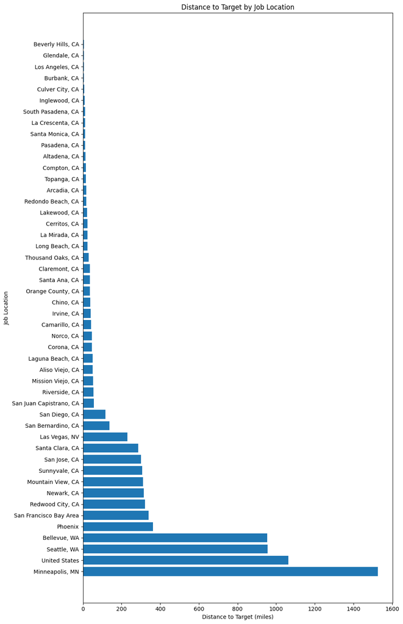

```python
# Keep only unique combinations of 'Job Location' and 'distance_to_target_miles' and sort # location info and cleaning
df_unique = df.drop_duplicates(subset=['Job Location', 'distance_to_target_miles'])
df_unique = df_unique.sort_values('distance_to_target_miles', ascending=False) # Change to ascending=True if you want it in the opposite order


# Create a figure and axis
fig, ax = plt.subplots(figsize=(10, len(df_unique) * 0.4)) # Adjust the size as needed

# Bar plot
ax.barh(df_unique['Job Location'], df_unique['distance_to_target_miles'])

# Label the axes
ax.set_xlabel('Distance to Target (miles)')
ax.set_ylabel('Job Location')

# Add a title
ax.set_title('Distance to Target by Job Location')

# Display the plot
plt.show()
```

```python
f_name = '/Users/phil/Dropbox/GITHUB/DATA/scrapifurs/pandas_df/final_df_data_scientist_search_v2'
utils.save_obj(df, f_name+'.pkl', pickle.HIGHEST_PROTOCOL)
df.to_csv(f_name+'.csv', index=False)
```

# some data exploration

```python
f_name = '/Users/phil/Dropbox/GITHUB/DATA/scrapifurs/pandas_df/final_df_data_scientist_search_v2'
df = utils.load_obj(f_name)
df
```

|  | Job Titles | Job Location | Company Name | Company Name_CLEANED_BY_GPT | latitude | longitude | distance_to_target_miles |
| --- | --- | --- | --- | --- | --- | --- | --- |
| 0 | Incoming Data Scientist at Chevron \| USC Alum | Los Angeles, CA | Chevron | Chevron | 34.053691 | -118.242766 | 5.838454 |
| 1 | Data Scientist at eBay | Los Angeles, CA | eBay | eBay | 34.053691 | -118.242766 | 5.838454 |
| 2 | Data Scientist at Twitter | Los Angeles, CA | Twitter | Twitter | 34.053691 | -118.242766 | 5.838454 |
| 3 | Data Scientist \| Petroleum Engineer | Los Angeles, CA | Phillips 66 | Phillips 66 | 34.053691 | -118.242766 | 5.838454 |
| 4 | Data Scientist at Snap Inc. | Los Angeles, CA | Snap Inc. | Snap Inc. | 34.053691 | -118.242766 | 5.838454 |
| ... | ... | ... | ... | ... | ... | ... | ... |
| 373 | Data Scientist | Los Angeles, CA | Data Scientist II at Nordstrom | Nordstrom | 34.053691 | -118.242766 | 5.838454 |
| 374 | Data Scientist | Los Angeles, CA | Data Scientist at BCG GAMMA | BCG GAMMA | 34.053691 | -118.242766 | 5.838454 |
| 375 | Data Scientist | Los Angeles, CA | Data Scientist at Rule14 LLC | Rule14 LLC | 34.053691 | -118.242766 | 5.838454 |
| 376 | Data Analyst \| Data Scientist | Los Angeles, CA | None (No Company Mentioned) | None | 34.053691 | -118.242766 | 5.838454 |
| 377 | Data Science Intern @ Chewy | Los Angeles, CA | Data Scientist at Chewy | Chewy | 34.053691 | -118.242766 | 5.838454 |

378 rows × 7 columns

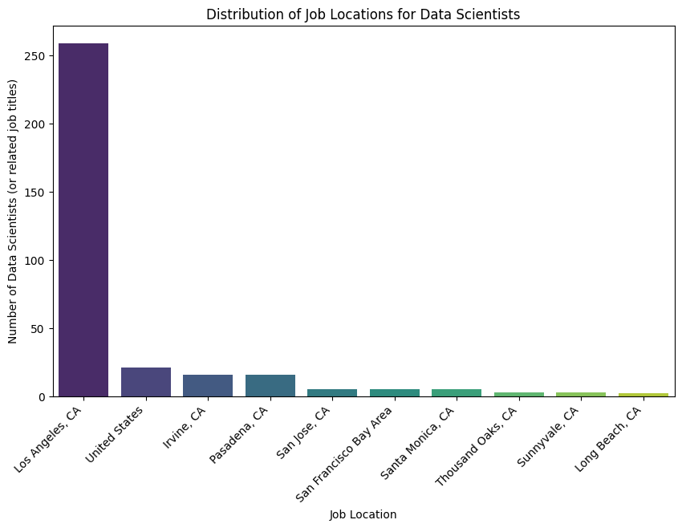

```python
# Getting the distribution of job locations
job_location_counts = df['Job Location'].value_counts().nlargest(10)

# Plotting the distribution of job locations
plt.figure(figsize=(10, 6))
sns.barplot(x=job_location_counts.index, y=job_location_counts.values, palette="viridis")
plt.title('Distribution of Job Locations for Data Scientists')
plt.xlabel('Job Location')
plt.ylabel('Number of Data Scientists (or related job titles)')
plt.xticks(rotation=45, ha="right")
plt.show()
```

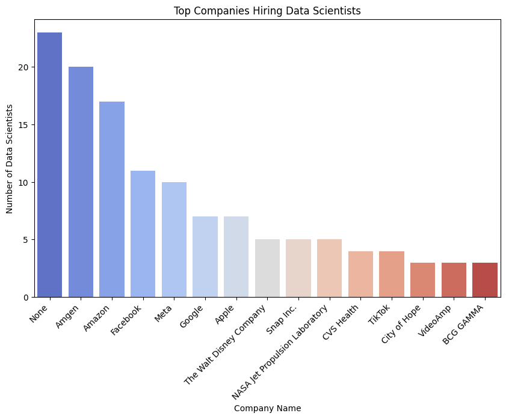

```python
# Getting the top companies hiring data scientists
top_companies_counts = df['Company Name_CLEANED_BY_GPT'].value_counts().nlargest(15)
# top_companies_counts = df['Company Name'].value_counts().nlargest(15)


# Plotting the top companies hiring data scientists
plt.figure(figsize=(10, 6))
sns.barplot(x=top_companies_counts.index, y=top_companies_counts.values, palette="coolwarm")
plt.title('Top Companies Hiring Data Scientists')
plt.xlabel('Company Name')
plt.ylabel('Number of Data Scientists')
plt.xticks(rotation=45, ha="right")
plt.show()
```

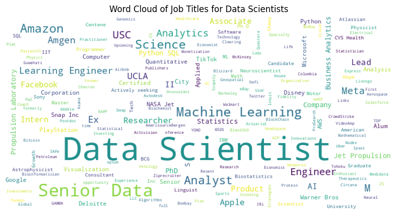

```python
from wordcloud import WordCloud


# Concatenating all the job titles into a single string
job_titles_text = " ".join(title for title in df['Job Titles'])

# Creating a word cloud
wordcloud = WordCloud(background_color='white', width=800, height=400).generate(job_titles_text)

# Displaying the word cloud
plt.figure(figsize=(10, 5))
plt.imshow(wordcloud, interpolation='bilinear')
plt.axis("off")
plt.title('Word Cloud of Job Titles for Data Scientists')
plt.show()
```

```python
import plotly.offline as pyo
pyo.init_notebook_mode(connected=True)


# Assume company_color_map already exists
company_color_map = {
    'None': 'gray',
    'Amgen': 'blue',
    'Amazon': 'goldenrod',
    'Facebook': 'dodgerblue',
    'Meta': 'dodgerblue',
    'Google': 'red',
    'Apple': 'silver',
    'The Walt Disney Company': 'mediumpurple',
    'Snap Inc.': 'yellow',
    'NASA Jet Propulsion Laboratory': 'midnightblue',
    'CVS Health': 'forestgreen',
    'TikTok': 'red',
    'City of Hope': 'darkorange',
    'VideoAmp': 'cyan',
    'BCG GAMMA': 'limegreen',
    'ZipRecruiter': 'teal',
    'Nordstrom': 'black',
    'Walmart': 'navy'
}

steps_tmp = [5,6, 7, 8, 9, 10,11, 12, 13, 14, 15, 20, 25, 30, 35, 40, 45, 50, 100, 200, 300, np.inf]
max_distance = np.max(steps_tmp)

# Steps for the slider
steps = []
N_companies = 8

# Get the maximum y value to lock the y-axis
y_max_value = df[df['distance_to_target_miles'] <= max_distance]['Company Name_CLEANED_BY_GPT'].value_counts().nlargest(N_companies).max()
y_max_value = np.ceil(y_max_value/5)*5


for step in steps_tmp:
    filtered_df = df[df['distance_to_target_miles'] <= step]
    top_companies_counts = filtered_df['Company Name_CLEANED_BY_GPT'].value_counts().nlargest(N_companies)

    # wrap the text for the color map and the original data
    top_companies_counts.index = ['<br>'.join(k.split(' ')) for k in top_companies_counts.index]
    company_color_map = {('<br>'.join(k.split(' '))): v for k, v in company_color_map.items()}

    step_dict = {
        "args": [
            {"y": [top_companies_counts.values], "x": [top_companies_counts.index],
             "marker.color": [top_companies_counts.index.map(company_color_map).tolist()]},
        ],
        "label": str(step),
        "method": "restyle"
    }

    steps.append(step_dict)

fig = go.Figure()
# Add trace
fig.add_trace(go.Bar(
    x=top_companies_counts.index, #top_companies_counts.index,
    y=top_companies_counts.values,
    name="Companies",
    marker_color=top_companies_counts.index.map(company_color_map).tolist()
))

# Add sliders and lock y-axis
fig.update_layout(
    sliders=[{
        "active": 10,
        "yanchor": "top",
        "xanchor": "left",
        "currentvalue": {
            "font": {"size": 20},
            "prefix": "Max Distance: ",
            "visible": True,
            "xanchor": "left"
        },
        "transition": {"duration": 300, "easing": "cubic-in-out"},
        "pad": {"b": 10, "t": 50},
        "len": 0.9,
        "x": 0.1,
        "y": 0,
        "steps": steps
    }],
    yaxis=dict(range=[0, y_max_value]),  # Lock the y-axis
    xaxis=dict(range=[-.5, N_companies-.5])
)

# fig.show()
pyo.iplot(fig)
```

[interactive chart not shown]

# Map out location and lists of jobs

```python
target_loc_str = ['hollywood california']
target_location = get_lat_lon(target_loc_str)
print(target_location)
home_location = target_location[target_loc_str[0]]
home_location
# home_location = (34.0980031, -118.329523)
```

```
100%|██████████████████████████████████████████████████████████████████████████████████████████████████████████████████████████████████| 1/1 [00:01<00:00,  1.22s/it]
```

```
{'hollywood california': (34.0980031, -118.329523)}
```

```
(34.0980031, -118.329523)
```

```python
def get_top_n_companies(df, column_name, n=20):
    """Retrieve the top n companies based on occurrence."""
    return df[column_name].value_counts().nlargest(n).index

def create_grouped_data(df, column_name):
    """Group data by company name and create aggregated information."""
    grouped_counts = df.groupby(column_name).size()
#     companies_text = '<br>'.join([f'{company} (Count: {count})' for company, count in grouped_counts.items()])
#     companies_text = '<br>'.join([f'{count:02}:{company}' for company, count in sorted(grouped_counts.items(), key=lambda x: x[1], reverse=True)])
    companies_text = '<br>'.join([f'{count:>2}: {company}' for company, count in sorted(grouped_counts.items(), key=lambda x: x[1], reverse=True)])


    total_count = grouped_counts.sum()
    return {'companies': companies_text, 'count': total_count}

def get_color_scale(breakpoints, cmap_name='turbo'):
    """Generate a custom color scale based on provided breakpoints using a colormap."""
    cmap = plt.get_cmap(cmap_name)
    normalized_breakpoints = (np.log(breakpoints) - np.log(breakpoints[0])) / (np.log(breakpoints[-1]) - np.log(breakpoints[0]))
    color_values = [cmap(value) for value in normalized_breakpoints]
    color_strings = [f"rgb({int(r*255)}, {int(g*255)}, {int(b*255)})" for r, g, b, _ in color_values]
    return list(zip(normalized_breakpoints, color_strings))

# Assuming df is loaded here as your DataFrame
column_name = 'Company Name_CLEANED_BY_GPT'
top_companies = get_top_n_companies(df, column_name)
df_filtered = df[df[column_name].isin(top_companies)]

grouped_data = df_filtered.groupby(['latitude', 'longitude']).apply(lambda x: create_grouped_data(x, column_name)).reset_index(name='data')

grouped_data['hover_text'] = grouped_data['data'].apply(lambda x: f"Companies:<br>{x['companies']}")

breakpoints = [1, 2, 3, 4, 5, 10, 25, 50, 100]
scatter_trace = go.Scattermapbox(
    lat=grouped_data['latitude'],
    lon=grouped_data['longitude'],
    text=grouped_data['hover_text'],
    mode='markers',
    marker=dict(
        color=np.log(grouped_data['data'].apply(lambda x: x['count'])),
        opacity=0.6,
        size=20,
        colorscale=get_color_scale(breakpoints),
        cmin=np.log(breakpoints[0]),
        cmax=np.log(breakpoints[-1]),
        colorbar=dict(
            title="Company count",
            tickvals=np.log(breakpoints),
            ticktext=breakpoints
        )
    ),
    showlegend=False
)



# home_location = (34.0980031, -118.329523)
home_trace = go.Scattermapbox(
    lat=[home_location[0]],
    lon=[home_location[1]],
    text=['HOME'],  # Set the text as HOME
    mode='markers+text',  # Use both markers and text
    marker=go.scattermapbox.Marker(
        symbol='circle',
        size=10,  # Adjust size as necessary
        color='red',  # Set the color of the marker
        opacity=1  # Full opacity for the circle
    ),
    textposition='bottom right',  # Position the text relative to the marker
    showlegend=False
)


layout = go.Layout(
    mapbox=dict(
        style="carto-positron",
        center={"lat": home_location[0], "lon": home_location[1]},
        zoom=8
    ),
    title="Data Science Jobs Map From My 2nd Degree Connections"
)

fig = go.Figure(data=[scatter_trace, home_trace], layout=layout)
fig.show()

# import plotly.offline as pyo
# pyo.plot(fig, filename='your_output_file_name.html', auto_open=True)
```

[interactive chart not shown]